# Index

## Chart 2

```r
library(tidyverse)
```

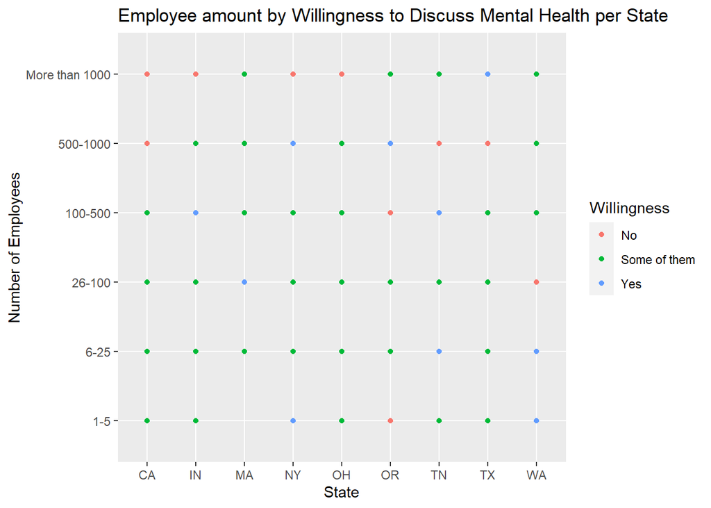

```r
library(dplyr)
library(ggplot2)
survey_df <- read.csv("~/INFO201/final-project-MinHeo1/survey.csv")
state_df <- survey_df %>%
  filter(Country == "United States") %>%
  group_by(state) %>%
filter(state=="CA" || state=="NY" || state=="WA" || state=="TX" || state=="OR" || state=="IN" || state=="MA" || state=="OH" || state=="TN")
  ordered_no_employees <- factor(state_df$no_employees, levels=c("1-5", "6-25", "26-100", "100-500", "500-1000", "More than 1000"))
ggplot(state_df, aes(x=state, y=ordered_no_employees)) + geom_point(aes(col=coworkers)) + labs(title="Employee amount by Willingness to Discuss Mental Health per State", y="Number of Employees", x="State", color="Willingness")
```

The purpose of this chart was to show the willingness of businesses (with differing number of employees) to talk about mental health with other coworkers. The graph demonstrates that the more employees they have the more unwilling they seem to want to talk about mental health with their coworkers (with Texas the only state willing to talk). Although the graph doesn’t have any concrete assumptions, an assumption that can be made is that the willingness to talk about mental health is still seemingly taboo. Only a few businesses are willing to talk about mental health with the majority of them reluctant or against talking about mental health.

## Chart 3

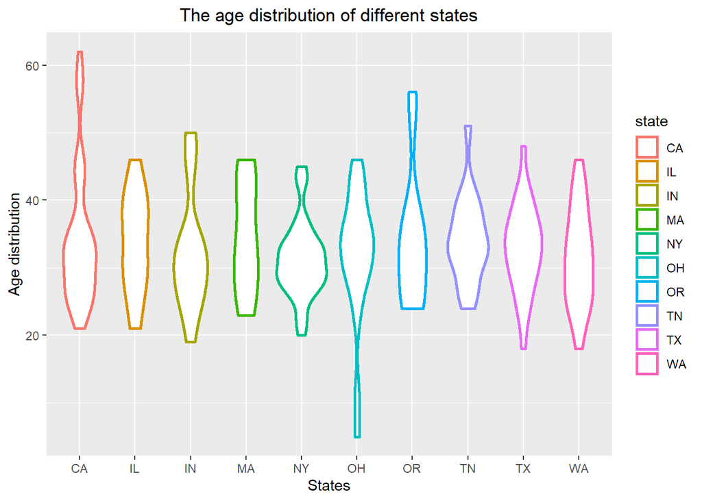

```r
my_df <- df[-c(94), ]
View(my_df)

state_group <- my_df %>%
  group_by(state)
View(state_group)
ggplot(my_df, aes(x = state, y = Age, color = state)) +
  geom_violin(size = 1) + labs(title = "The age distribution of different states", x="States", y = "Age distribution") + theme(plot.title = element_text(hjust = 0.5))
```

The purpose of this chart is to show the distribution of mental health issues among different ages. As seen the bulk of mental health issues occurred around the ages 20-40 which is when most people are in their “peak” of their careers. Meaning that they have to worry about promotions, salaries, family, etc. Thus, the chart isn’t surprising in any way, although there are some outlirs (such as Ohio having someone report around the age of 5). Most states don’t seem to have mental health issues after the age of around 45, although this could in part due to the older generation not reporting (or unwilling to report, because again of the stigma against mental health). Another interesting observation is that the ages is consistent among all shown states which shows that the rate (and age) of mental health is similar in states and that mental health can impact anybody anywhere.